# Notebook

### Фактический запуск 14.09.2026

Все вычислительные ячейки выполнены. Техническое исполнение не подтверждает научные интерпретации исторического текста. Полный журнал — `legacy-execution.json`.

## Статус воспроизведения исторической редакции

Повторный технический запуск не подтверждает научные выводы старой редакции. Ниже сохранены прежние допущения и интерпретации; их следует сверять с текущими правилами проекта. Дыхательная и ЭКГ-разметка исторических расчётов не получает статус принятой при повторном запуске. Значения толщины 15 и 40 мм — исторические сценарии, а не заново проверенные измерения по КТ. Старые оценки сердечного происхождения сигнала и функций сердца не считаются валидированными.

```
Исторические входы скопированы; запись в исходные метки и параметры исключена.
```

# Скетч: двуслойная модель «мягкие ткани — лёгкое» по эксперименту

**Два испытуемых** (у каждого своя толщина мягких тканей h):

- **Георгий** — h = 40 мм, файлы `<размер>georg.csv`;
- **Ник** — h = 15 мм, файлы `<размер>nik.csv`.

Канал `BASE_2_Ω` — размер-варьируемая сборка над лёгким (моделируем). Размер = L = 2a; a = L/2, b = a/(a/b).

**Графики:**

В заголовке каждого графика: **что зафиксировано** и **что варьируется**.

## §0. Назначение скетча и словарь терминов

Это предварительный (обзорный) расчёт двуслойной полубесконечной модели на данных эксперимента: проверка формы кривой зондирования и оценка расчётного дыхательного размаха импеданса. Строгие версии тех же расчётов вынесены в отдельные ноутбуки: разметка сигналов — 08, статическая оценка удельных сопротивлений — 09, систолические приращения — 11.

### Словарь терминов

Основные термины (двуслойная полубесконечная модель, электродная сборка, тетраполярный метод, базовый и пульсовой импеданс каналов 1 и 2, прямая и обратная задача) определены в §0 ноутбука 09. Дополнительно используются:

- **Обратная задача по одному размеру** — восстановление удельного сопротивления лёгкого ρ₂ по измеренному импедансу при заданных удельном сопротивлении мягких тканей ρ₁ и толщине слоя мягких тканей h; решается численно, так как импеданс монотонен по ρ₂.
- **Кривая зондирования** — зависимость кажущегося удельного сопротивления (§0 [09]) от размера электродной сборки; её форма отражает переход от сопротивления мягких тканей к сопротивлению лёгкого.
- **Вентиляционный размах импеданса** — разность импеданса между вдохом и выдохом при одном размере сборки, обусловленная изменением сопротивления лёгкого при дыхании.

**Входные данные.** Толщина слоя мягких тканей h из компьютерной томографии: Георгий 40 мм, Ник 15 мм; путь к исходным записям и меткам.

**Допущения.** Толщина считается постоянной в пределах испытуемого; конфигурация задаёт общие для скетча параметры.

```
Испытуемые: Георгий (h=40 мм), Ник (h=15 мм)
```

**Анализ результатов.** Выведены испытуемые и их толщины.

**Результаты и умозаключения.** Конфигурация — общий вход для последующих ячеек скетча.

## §1. Двуслойная модель и обратная задача

**Входные данные.** Толщина h из томографии; исходные записи базового импеданса канала 2 и метки задержек дыхания из 08.

**Допущения.** Прямая задача — двуслойная полубесконечная модель (§0 09), формула (7.1):

$$Z=\frac{\rho_1}{\pi}\left(\frac{1}{a-b}-\frac{1}{a+b}\right)+\frac{2\rho_1}{\pi}\sum_{i=1}^{N}k^{\,i}\left(\frac{1}{\sqrt{(a-b)^2+(2ih)^2}}-\frac{1}{\sqrt{(a+b)^2+(2ih)^2}}\right) \tag{7.1}$$

где Z — импеданс сборки, Ом; ρ₁, ρ₂ — удельные сопротивления мягких тканей и лёгкого, Ом·м; a, b — половины токовой и потенциальной баз, м; h — толщина слоя мягких тканей, м; k = (ρ₂ − ρ₁)/(ρ₂ + ρ₁) — коэффициент отражения границы; N — число членов ряда. Обратная задача по одному размеру решается численно, так как импеданс монотонен по ρ₂.

```
Георгий : размеры [np.int64(50), np.int64(60), np.int64(70), np.int64(80), np.int64(90), np.int64(100), np.int64(110), np.int64(120), np.int64(130), np.int64(140)] | ρ1≈11.52 Ом·м | h=40 мм
Ник     : размеры [np.int64(50), np.int64(60), np.int64(70), np.int64(80), np.int64(90), np.int64(100), np.int64(110), np.int64(120), np.int64(130), np.int64(140)] | ρ1≈5.00 Ом·м | h=15 мм
```

**Анализ результатов.** Модель и обратная задача определены; данные загружены, для каждого испытуемого доступен набор размеров сборок.

**Результаты и умозаключения.** Функции прямой и обратной задачи и загруженные данные — вход для §2 (кривые зондирования) и §3 (расчётный размах).

## §2. Обзор сигналов и кривая зондирования (оба испытуемых)

**Допущения.** Обзор временных рядов служит визуальной проверкой качества сигналов перед количественным анализом.

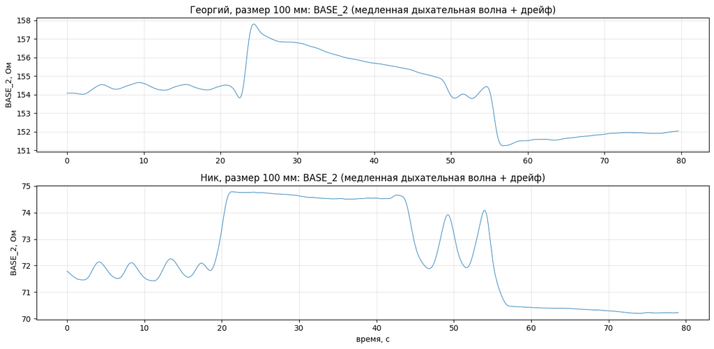

**Результаты и умозаключения.** Качество сигналов приемлемо для дальнейшего анализа; строгая сегментация выполняется в 08.

**Входные данные.** Базовый импеданс канала 2 на задержках дыхания по всем размерам сборок для обоих испытуемых.

**Допущения.** Строится кривая зондирования — зависимость кажущегося удельного сопротивления от размера сборки, формула (7.2):

$$\rho_a(L)=Z(L)\cdot\frac{\pi\,(a^2-b^2)}{2b} \tag{7.2}$$

где ρ_a — кажущееся удельное сопротивление, Ом·м; Z(L) — базовый импеданс сборки размера L, Ом; a, b — половины баз, м. Величина интерпретирующая (§0 [09]): при малом размере стремится к ρ₁, при большом — к ρ₂.

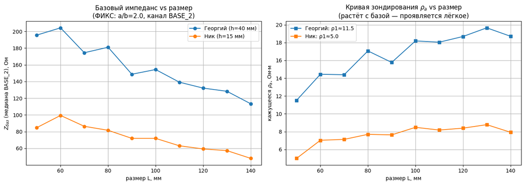

**Результаты и умозаключения.** Форма кривых согласуется с моделью; количественная оценка удельных сопротивлений и их определимости — в 09.

## §3. Расчётный дыхательный размах $\Delta Z_{\text{вент}}$ (модель, без данных)

**Входные данные.** Прямая задача (7.1) при наборе значений толщины h и фиксированной форме сборки β = b/a = 0.5 (модельный расчёт, данные не используются).

**Допущения.** Расчётный дыхательный размах импеданса — разность модельного импеданса при вдохе и выдохе, формула (7.3):

$$\Delta Z_{\text{вент}}(L)=Z(\rho_1,\rho_2^{\text{вд}},h)-Z(\rho_1,\rho_2^{\text{выд}},h) \tag{7.3}$$

где ΔZ_вент — дыхательный размах импеданса, Ом; ρ₂вд, ρ₂выд — удельное сопротивление лёгкого на вдохе и выдохе, Ом·м. Расчёт модельный, без данных, для оценки ожидаемого сигнала.

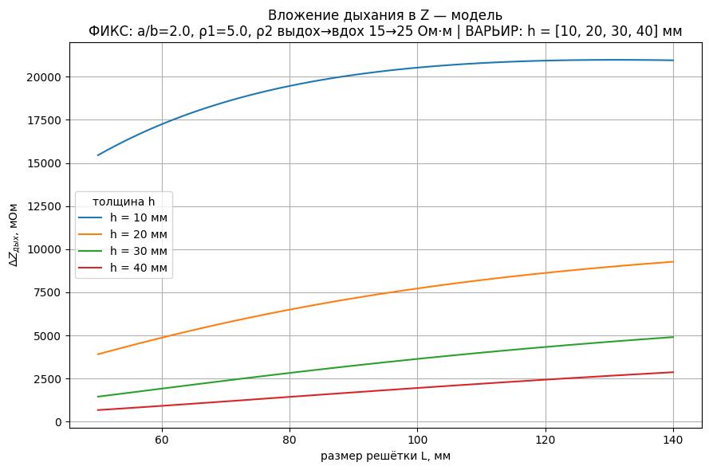

**Результаты и умозаключения.** При большой толщине дыхательный сигнал мал, что предвещает пониженную определимость ρ₂ у толстого испытуемого (строго — 09 §3.1).

**Входные данные.** Прямая задача (7.1) при наборе значений формы сборки β = b/a, отдельно для толщины 40 и 15 мм (модельный расчёт).

**Допущения.** Чтобы оценить влияние формы сборки на дыхательный сигнал, размах (7.3) вычисляется при разных β. Все реальные измерения выполнены при β = 0.5, поэтому результат по β — модельная оценка.

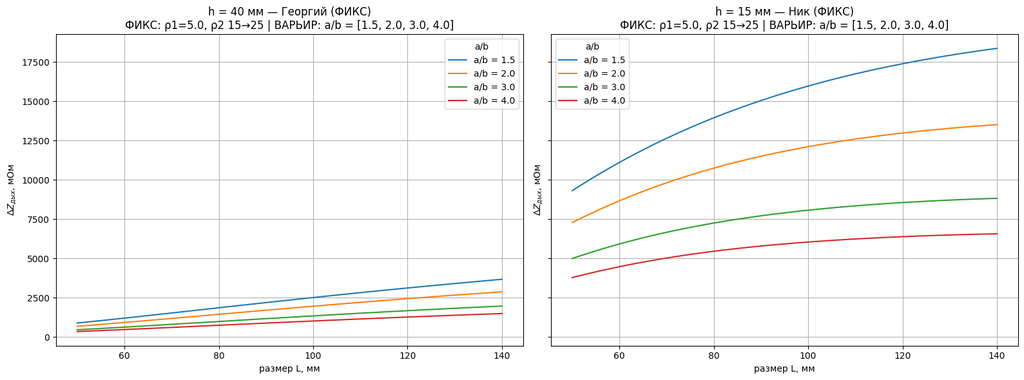

**Результаты и умозаключения.** Оптимизация формы сборки — модельная рекомендация для будущих измерений; строгий расчёт по матрице Фишера — в 05 §8.